# LogisticRegressionWeek04

Dr.B

Tuesday, May 26, 2015

```r
# Load functions
source('functions.R')

# Load the libraries
library(e1071)
library(epitools)
```

## Build the Data

One very common type of data set in biomedical statistics is a cohort study, where you have information on people who were exposed to some treatment or environment (for example, people who took a certain drug, or people who smoke) and also on whether the same people have a particular disease or not. Your data set would look something like this:

```r
## New Problem
df0<- data.frame(cbind (Ind=rep("Exposed",21),Dep=rep("Sick",21)))
df1<- data.frame(cbind (Ind=rep("Exposed",6),Dep=rep("NotSick",6)))
total <- rbind(df0, df1)
df0<- data.frame(cbind (Ind=rep("NotExposed",22),Dep=rep("Sick",22)))
df1<- data.frame(cbind (Ind=rep("NotExposed",51),Dep=rep("NotSick",51)))
total <- rbind(total, df0)
total <- rbind(total, df1)
rm(df0,df1)
```

## Format 2X2 Table

```r
x<-table(total$Dep,total$Ind,deparse.level = 2)
x
```

```
##          total$Ind
## total$Dep Exposed NotExposed
##   Sick         21         22
##   NotSick       6         51
```

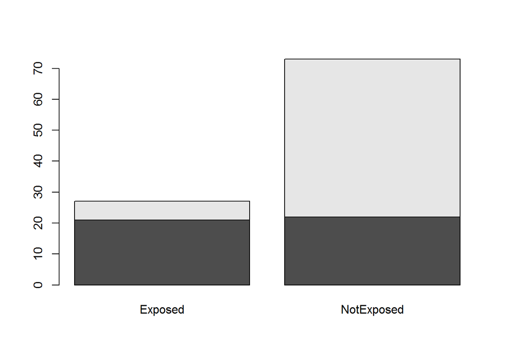

```r
#Calculate Chi Square and Cramer's V
#assocstats(x)

#crossTable
#CrossTable(x,format="SPSS")

##Grapics
barplot(x)
```

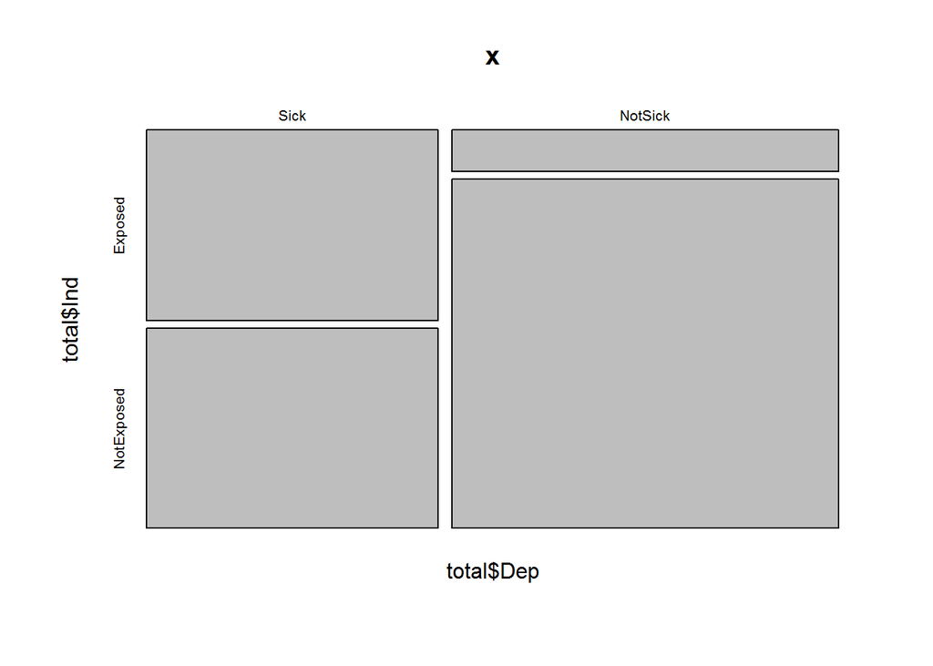

```r
mosaicplot(x)
```

```r
addmargins(x)
```

```
##          total$Ind
## total$Dep Exposed NotExposed Sum
##   Sick         21         22  43
##   NotSick       6         51  57
##   Sum          27         73 100
```

```r
prop.table(x,1) #row
```

```
##          total$Ind
## total$Dep    Exposed NotExposed
##   Sick    0.48837209 0.51162791
##   NotSick 0.10526316 0.89473684
```

```r
prop.table(x,2) #column
```

```
##          total$Ind
## total$Dep    Exposed NotExposed
##   Sick    0.77777778 0.30136986
##   NotSick 0.22222222 0.69863014
```

```r
prop.table(addmargins(x),1) #row
```

```
##          total$Ind
## total$Dep     Exposed  NotExposed         Sum
##   Sick    0.244186047 0.255813953 0.500000000
##   NotSick 0.052631579 0.447368421 0.500000000
##   Sum     0.135000000 0.365000000 0.500000000
```

```r
prop.table(addmargins(x),2) #column
```

```
##          total$Ind
## total$Dep    Exposed NotExposed        Sum
##   Sick    0.38888889 0.15068493 0.21500000
##   NotSick 0.11111111 0.34931507 0.28500000
##   Sum     0.50000000 0.50000000 0.50000000
```

```r
#Calculate Chi Square and Cramer's V
#assocstats(x)

#Chi squared test
chisq.test(x)
```

```
##
##  Pearson's Chi-squared test with Yates' continuity correction
##
## data:  x
## X-squared = 16.3596, df = 1, p-value = 0.000052389
```

```r
chisq.test(x)$expected  # expected counts under the null
```

```
##          total$Ind
## total$Dep Exposed NotExposed
##   Sick      11.61      31.39
##   NotSick   15.39      41.61
```

```r
chisq.test(x)$observed  # observed counts (same as M)
```

```
##          total$Ind
## total$Dep Exposed NotExposed
##   Sick         21         22
##   NotSick       6         51
```

```r
chisq.test(x)$residuals # Pearson residuals
```

```
##          total$Ind
## total$Dep    Exposed NotExposed
##   Sick     2.7558113 -1.6759843
##   NotSick -2.3935708  1.4556827
```

```r
chisq.test(x)$stdres    # standardized residuals
```

```
##          total$Ind
## total$Dep    Exposed NotExposed
##   Sick     4.2721906 -4.2721906
##   NotSick -4.2721906  4.2721906
```

## Calculating Relative Risks (Cohort Study)

The relative risk of having the disease given exposure is the probability of having the disease for people who were exposed to the treatment or environmental factor, divided by the probability of having the disease for people who were not exposed to that treatment or environmental factor.

```r
#Risk ratio and confidence intervals (IF CONTAI 1 NOT SIGN)
riskratio(x, method="wald")
```

```
## $data
##          total$Ind
## total$Dep Exposed NotExposed Total
##   Sick         21         22    43
##   NotSick       6         51    57
##   Total        27         73   100
##
## $measure
##          risk ratio with 95% C.I.
## total$Dep  estimate     lower     upper
##   Sick    1.0000000        NA        NA
##   NotSick 1.7488038 1.2887057 2.3731678
##
## $p.value
##          two-sided
## total$Dep     midp.exact   fisher.exact     chi.square
##   Sick                NA             NA             NA
##   NotSick 0.000024927501 0.000027377206 0.000019356198
##
## $correction
## [1] FALSE
##
## attr(,"method")
## [1] "Unconditional MLE & normal approximation (Wald) CI"
```

If the relative risk is 1 (ie. if the confidence interval includes 1), it means there is no evidence for an association between exposure and disease.

If the relative risk > 1, there is evidence of a positive association between exposure and disease

If the relative risk < 1, there is evidence of a negative association.

The relative risk can be estimated for a cohort study but not for a case-control study.

## Calculating Odds Ratios (Cohort or Case-Control Study)

As well as the relative risk of disease given exposure (to some treatment or environmental factor eg. smoking or some drug), you can also calculate the odds ratio for association between the exposure and the disease in a cohort study. The odds ratio is also commonly calculated in a case-control study.

The odds ratio for association between the exposure and the disease is the ratio of:

1. the probability of having the disease for people who were exposed to the treatment or environmental factor, divided by the probability of not having the disease for people who were exposed, and
2. the probability of having the disease for people who were not exposed to the treatment or environmental factor, divided by the probability of not having the disease for people who were not exposed.

```r
#Odds ratio and confidence intervals (IF CONTAI 1 NOT SIGN)
oddsratio.wald(x)
```

```
## $data
##          total$Ind
## total$Dep Exposed NotExposed Total
##   Sick         21         22    43
##   NotSick       6         51    57
##   Total        27         73   100
##
## $measure
##          odds ratio with 95% C.I.
## total$Dep  estimate     lower     upper
##   Sick    1.0000000        NA        NA
##   NotSick 8.1136364 2.8795635 22.861484
##
## $p.value
##          two-sided
## total$Dep     midp.exact   fisher.exact     chi.square
##   Sick                NA             NA             NA
##   NotSick 0.000024927501 0.000027377206 0.000019356198
##
## $correction
## [1] FALSE
##
## attr(,"method")
## [1] "Unconditional MLE & normal approximation (Wald) CI"
```

```r
## You can use
epitab(x)
```

```
## $tab
##          total$Ind
## total$Dep Exposed         p0 NotExposed         p1 oddsratio     lower
##   Sick         21 0.77777778         22 0.30136986 1.0000000        NA
##   NotSick       6 0.22222222         51 0.69863014 8.1136364 2.8795635
##          total$Ind
## total$Dep     upper        p.value
##   Sick           NA             NA
##   NotSick 22.861484 0.000027377206
##
## $measure
## [1] "wald"
##
## $conf.level
## [1] 0.95
##
## $pvalue
## [1] "fisher.exact"
```

If the odds ratio is 1 (ie. if the confidence interval includes 1), it means there is no evidence for an association between exposure and disease.

If the odds ratio > 1, there is evidence of a positive association between exposure and disease.

If the odds ratio < 1, there is evidence of a negative association.

The odds ratio can be estimated for either a cohort study or a case-control study.

## Model

```r
#Fit the model
fit<-glm(Dep~Ind,data=total,family=binomial(link="logit"))
```

## Fit Information

```r
d<-anova(fit,test='Chisq') # or d<-anova(fit,test='LRT')
d
```

```
## Analysis of Deviance Table
##
## Model: binomial, link: logit
##
## Response: Dep
##
## Terms added sequentially (first to last)
##
##
##      Df Deviance Resid. Df Resid. Dev    Pr(>Chi)
## NULL                    99    136.663
## Ind   1  18.7038        98    117.959 0.000015267 ***
## ---
## Signif. codes:  0 '***' 0.001 '**' 0.01 '*' 0.05 '.' 0.1 ' ' 1
```

If chi squared is significant, there is a relationship between exposure and sickness.

```r
cbind(Coeff = coef(fit),confint(fit)) # 95% CI for the coefficients using profiled log-likelihood
```

```
##                    Coeff      2.5 %      97.5 %
## (Intercept)   -1.2527630 -2.2551409 -0.40599596
## IndNotExposed  2.0935461  1.1083556  3.20685620
```

```r
cbind(Coeff = coef(fit),confint.default(fit)) # 95% CI for the coefficients using standard errors
```

```
##                    Coeff      2.5 %      97.5 %
## (Intercept)   -1.2527630 -2.1600494 -0.34547651
## IndNotExposed  2.0935461  1.0576393  3.12945298
```

```r
exp(cbind(OR = coef(fit), confint(fit))) ## odds ratios and 95% CI together
```

```
##                       OR      2.5 %      97.5 %
## (Intercept)   0.28571429 0.10485876  0.66631286
## IndNotExposed 8.11363636 3.02937266 24.70130795
```

```r
exp(cbind(OR = coef(fit), confint.default(fit))) ## odds ratios and 95% CI together using standard errors
```

```
##                       OR      2.5 %      97.5 %
## (Intercept)   0.28571429 0.11531942  0.70788296
## IndNotExposed 8.11363636 2.87956520 22.86147052
```

```r
# Get loglikelihood
logLik(fit)
```

```
## 'log Lik.' -58.979565 (df=2)
```

```r
m <- naiveBayes(Dep~Ind, data = total)
m
```

```
##
## Naive Bayes Classifier for Discrete Predictors
##
## Call:
## naiveBayes.default(x = X, y = Y, laplace = laplace)
##
## A-priori probabilities:
## Y
##    Sick NotSick
##    0.43    0.57
##
## Conditional probabilities:
##          Ind
## Y            Exposed NotExposed
##   Sick    0.48837209 0.51162791
##   NotSick 0.10526316 0.89473684
```